[Deriv.com](https://github.com/englianhu/binary.com-interview-question) - Interday High Frequency Trading Models Comparison

[®γσ, Lian Hu](https://englianhu.github.io/) ®

2021-01-20

# 1 Abstract

There has already 2 years passed by while [Binary.com-is-Rebranding-to-Deriv.com](https://derivdotcom.medium.com/binary-com-is-rebranding-to-deriv-com-and-here-is-everything-you-need-to-know-6f4a8513c84b), Here I summarized some previous research papers in [Binary.com → Deriv.com](https://englianhu.medium.com/binary-com-deriv-com-6058cdbfc3a1) and continue from this high-frequency-trading.

```r
if(!suppressPackageStartupMessages(require('BBmisc'))) {
  install.packages('BBmisc', dependencies = TRUE, INSTALL_opts = '--no-lock')
}
suppressPackageStartupMessages(require('BBmisc'))
# suppressPackageStartupMessages(require('rmsfuns'))

pkgs <- c('devtools', 'knitr', 'kableExtra', 'tint', 'dygraphs',
          'devtools','readr', 'lubridate', 'data.table',
          'feather', 'purrr', 'quantmod', 'tidyquant', 'plotly',
          'tibbletime', 'furrr', 'flyingfox', 'tidyr', 'jsonlite',
          'timetk', 'plyr', 'dplyr', 'stringr', 'magrittr', 'tdplyr',
          'tidyverse', 'memoise', 'htmltools', 'formattable',
          'zoo', 'forecast', 'seasonal', 'seasonalview', 'rjson',
          'rugarch', 'rmgarch', 'mfGARCH', 'sparklyr', 'jcolors',
          'microbenchmark', 'dendextend', 'lhmetools', 'ggthemr',
          'stringr', 'pacman', 'profmem', 'DescTools', 'ggthemes',
          'htmltools', 'echarts4r', 'viridis', 'hrbrthemes')

# https://github.com/mpiktas/midasr
# https://github.com/onnokleen/mfGARCH
# devtools::install_github("business-science/tibbletime")
# devtools::install_github("DavisVaughan/furrr")

suppressAll(lib(pkgs))
# load_pkg(pkgs)

funs <- c('uv_fx.R', 'opt_arma.R', 'multi_seasons.R',
          'filterFX.R', 'filter_spec.R', 'mv_fx.R',
          'task_progress.R', 'read_umodels.R', 'convertOHLC.R')
l_ply(funs, function(x) source(paste0('./function/', x)))

# spark_install()

# if(FALSE) {
  # Not run due to side-effects
#   spark_home_set()
#   }
# sc <- spark_connect(master = 'local')

#spark_install()
#sc <- spark_connect(master = 'local')

.cl = FALSE

Sys.setenv(TZ = 'Asia/Tokyo')
## options(knitr.table.format = 'html') will set all kableExtra tables to be 'html', otherwise need to set the parameter on every single table.
options(warn = -1, knitr.table.format = 'html')#, digits.secs = 6)
rm(pkgs, funs)
```

# 2 Introduction

By refer to *GARCH模型中的ARIMA(p,d,q)参数最优化* and *binary.com Interview Question I - Comparison of Univariate GARCH Models*, we know **Fractional Intergrated GJR-GARCH** is the best fit model. This paper we compare the MIDAS, GARCH-MIDAS and Levy Process models. Here I also test another high frequency trading model mcmcsGARCH. These paper might consider as comparison interday trading before start the high frequency trading via [Real Time FXCM](https://github.com/scibrokes/real-time-fxcm).

*High Frequency Financial Time Series Prediction - Machine Learning Approach* introduce multilayer modelling for high-frequency-trading. *binary.com Interview Question I - Tick-Data-HiLo For Daily Trading* (Blooper) tried to use Hi-Lo daily dataset for modelling but failed. The paper recommend to use complete itraday dataset.

> I noticed that buying early in the morning, around 5am eastern time, tends to give lower prices and selling around 10pm eastern time gives you the highest prices. The wording is weird but i want to know your opinions on how time of day affects the bitcoin trading market. Thank you.

*Source : [Time of day affects trading prices](https://www.reddit.com/r/Bitcoin/comments/7hdtnw/time_of_day_affects_trading_prices/)*

From above quotes, we can know the seasonality of price trend daily, weekly, monthly or annually etc. MIDAS and mcsGARCH are the models designate for high frequency trading.

*A Comparison of GARCH-class Models and MIDAS Regression with Application in Volatility Prediction and Value at Risk Estimation* compares GARCH, eGARCH and MIDAS 3 models with normal and student distribution with matrix. The author concludes that the MIDAS model is the most accurate in volatility prediction but there is inconclusive for VaR 1% and 5%.

> Note that there does not seem to be an option to use SARMA models in the “rugarch” package, so you will have to let the “S” part go. But if there is a seasonal pattern (and that is quite likely when it comes to tourist arrivals), you will have to account for it somehow. Consider using exogenous seasonal variables (dummies or Fourier terms) in the conditional mean model via the argument external.regressors inside the argument mean.model in function ugarchspec. Alternatively, note that a SARMA model corresponds to a restricted ARMA model. An approximation of SARMA could thus be an ARMA with the appropriate lag order but without the SARMA-specific parameter restrictions (since those might not be available in “rugarch”).

The quotes above describe about the seasonal factors onto the model which is similar with MIDAS model, kindly refer to [Fitting ARIMA-GARCH model using “rugarch” package](https://stats.stackexchange.com/questions/176550/fitting-arima-garch-model-using-rugarch-package?answertab=votes#tab-top).

# 3 Data

## 3.1 Tick Data

### 3.1.1 Get Data

Due to the dataset gather via `getSymbols('JPY=X', src='av', api.key=api, periodicity='intraday')` is tidied but only 100 observations. Moreover I cannot select the time period from few years ago, therefore here I omit it and use the intraday data gather from [`real-time-fxcm/data/USDJPY/`](https://github.com/scibrokes/real-time-fxcm/tree/master/data/USDJPY) from `Y2015W1` to `Y2018W27`, due to the dataset is tick-data-base and more than 1 million observation per file (per week) and there has 4 years dataset where. Here I need to backtest day-by-day. There will be spent a long time to do.

- [Chapter 7 Importing Financial Data from the Internet](https://msperlin.github.io/pafdR/importingInternet.html) introduce few packages where provides api service.
- [High Frequency Data Price (Sample)](https://raw.githubusercontent.com/DavisVaughan/fin-econ-project-bitcoin/master/data/cleaned/cleaned-bitstamp-minutely.csv) is an example for intraday high-frequency-trading.

```r
cr_code <- c('AUDUSD=X', 'EURUSD=X', 'GBPUSD=X', 'CHF=X', 'CAD=X', 'CNY=X', 'JPY=X')

names(cr_code) <- c('AUDUSD', 'EURUSD', 'GBPUSD', 'USDCHF', 'USDCAD', 'USDCNY', 'USDJPY')
# names(cr_code) <- c('USDAUD', 'USDEUR', 'USDGBP', 'USDCHF', 'USDCAD', 'USDCNY', 'USDJPY')

dtr <- str_extract_all(getwd(), '.*/', '')[1]
dtr1 <- paste0(dtr, 'real-time-fxcm/data/')

## Read presaved FXCM data.
# mbase <- sapply(names(cr_code), function(x) readRDS(paste0('./data/', x, '.rds')) %>% na.omit)

fls <- sapply(names(cr_code), function(x) {
  dtr1 <- paste0(dtr1, x)
  list.files(dtr1, pattern = '^Y[0-9]{4}W[0-9]{1,2}.rds$') %>%
    str_replace_all('.rds', '')
  })
fls[lengths(fls) == 0] <- NA_character_
fls[is.na(fls)] <- NULL

# AUDUSD <- sapply(fls[[1]], read_rds)
# EURUSD <- sapply(fls[[2]], read_rds)
# GBPUSD <- sapply(fls[[3]], read_rds)
# USDCHF <- sapply(fls[[4]], read_rds)
# USDCAD <- sapply(fls[[5]], read_rds)
# USDCNY <- sapply(fls[[6]], read_rds)
# mbase <- llply(as.list(fls[[7]]), read_rds) #185 files where 1 files contains 1 million observation.

## Here I take USDJPY as example...
dtr1s <- paste0(dtr1, names(fls[length(fls)]))
fs <- list.files(dtr1s, pattern = '^Y[0-9]{4}W[0-9]{1,2}.rds$') %>%
  str_replace_all('.rds', '')
# eval(parse(text = paste0(fs, "<- readRDS('", fls[[7]], "') %>% as_tibble")))

t.unit <- c('seconds', 'minutes', 'hours', 'days', 'weeks', 'months', 'quarters', 'quarters')
## https://www.alphavantage.co/
## https://www.alphavantage.co/support/#api-key
# api = 'UL7EPVVEGDVC3TXC'
# getSymbols('JPY=X', src='av', api.key=api, periodicity='intraday')
```

[binary.com Interview Question I - Multivariate GARCH Models](http://rpubs.com/englianhu/binary-Q1Multi-GARCH) concludes that the multivariate will be more accurate but due to save time, here I only use univariate for models comparison.

Due to high volume of dataset, here I only use `USDJPY` since the variance is higher than the rest of currencies.

```r
## Read raw dataset.
#Y2015W1 <- read_rds(paste0(dtr1, '/', fls[[7]][1], '.rds')) %>% as_tibble

eval(parse(text = paste0(fs[1], "<- readRDS('", dtr1, "/",
                         names(fls[length(fls)]), '/', fls[length(fls)][[1]][1],
                         ".rds') %>% as_tibble")))

## raw dataset
Y2015W1
```

```
## # A tibble: 1,775,999 x 3
##    DateTime                  Bid   Ask
##    <fct>                   <dbl> <dbl>
##  1 01/04/2015 22:00:00.165  120.  121.
##  2 01/04/2015 22:00:00.197  120.  121.
##  3 01/04/2015 22:00:00.401  120.  121.
##  4 01/04/2015 22:00:00.712  120.  121.
##  5 01/04/2015 22:00:00.742  120.  121.
##  6 01/04/2015 22:00:00.786  120.  121.
##  7 01/04/2015 22:00:00.920  120.  121.
##  8 01/04/2015 22:00:00.926  120.  121.
##  9 01/04/2015 22:00:01.253  120.  121.
## 10 01/04/2015 22:00:01.259  120.  121.
## # ... with 1,775,989 more rows
```

Above table shows the raw tick-dataset (shows price fluctuation in mili-seconds). As we know that the variance in unit `mili-second` is almost 0. Therefore I refer to *High Frequency GARCH: The multiplicative component GARCH (mcsGARCH) model* and use 1 minute as 1 time unit, convert from univariate `ask` and univariate `bid` to be OHLC dataset.

### 3.1.2 Tidy Data

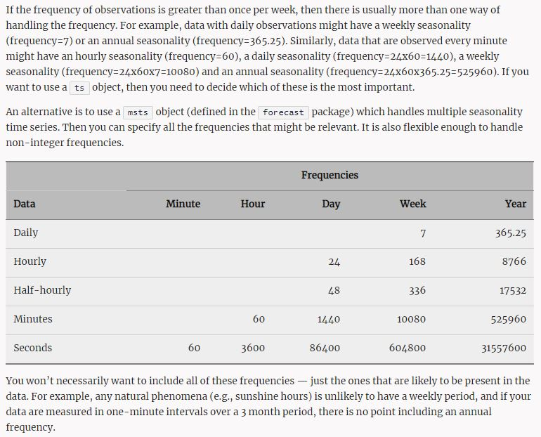

> For example, the `taylor` data set from the `forecast` package contains half-hourly electricity demand data from England and Wales over about 3 months in 2000. It was defined as `taylor <- msts(x, seasonal.periods=c(48,336)`.

*Source [Seasonal periods](https://robjhyndman.com/hyndsight/seasonal-periods/)*

*A Review of Literature on Time Zone Difference and Trade* study about trading across timezone and different country, if the timezone difference will affect the trading.

> I would like to use R for time series analysis. I want to make a time-series model and use functions from the packages timeDate and forecast. I have intraday data in the CET time zone (15 minutes data, 4 data points per hour). On March 31st daylight savings time is implemented and I am missing 4 data points of the 96 that I usually have. On October 28th I have 4 data points too many as time is switched back. For my time series model I always need 96 data points, as otherwise the intraday seasonality gets messed up. Do you have any experiences with this? Do you know an R function or a package that would be of help to automat such data handling - something elegant? Thank you!

> I had a similar problem with hydrological data from a sensor. My timestamps were in UTC+1 (CET) and did not switch to daylight saving time (UTC+2, CEST). As I didn’t want my data to be one hour off (which would be the case if UTC were used) I took the %z conversion specification of strptime. In ?strptime you’ll find: `%z` Signed offset in hours and minutes from UTC, so -0800 is 8 hours behind UTC. For example: In 2012, the switch from Standard Time to DST occured on 2012-03-25, so there is no 02:00 on this day. If you try to convert “2012-03-25 02:00:00” to a POSIXct-Object,

```r
## https://stackoverflow.com/questions/29202021/r-how-to-extract-dates-from-a-time-series
getTStime <- function(ats){
  start <- start(ats)
  end <- end(ats)
  time <- list()
  time[[1]] <- start
  m <- 2
  while(!(identical(start, end))){
    start[2] <- start[2] + 1
    if (start[2]==1441){ #mins per day
      start[1] <- start[1] + 1
      start[2] <- 1
    }
    time[[m]] <- start
    m <- m + 1
  }
  return(time)
}

## https://stackoverflow.com/questions/13865172/handling-data-on-the-days-when-we-switch-to-daylight-savings-time-and-back-in-r
```

```
#> as.POSIXct("2012-03-25 02:00:00", tz="Europe/Vienna")
```

```r
#[1] "2012-03-25 CET"
#
## you don't get an error or a warning, you just get date without the time (this behavior is documented).
## Using `format = "%z"` gives the desired result:
#
```

```
#> as.POSIXct("2012-03-25 02:00:00 +0100", format="%F %T %z", tz="Europe/Vienna")
```

```r
#[1] "2012-03-25 03:00:00 CEST"

## function
as.POSIXct.no.dst <- function (
  x, tz = '', format='%Y-%m-%d %H:%M', offset='+0100', ...) {
  x <- paste(x, offset)
  format <- paste(format, '%z')
  res <- as.POSIXct(x, tz, format=format, ...)
  return(res)
  }
```

*Source : [Handling data on the days when we switch to daylight savings time and back in R](https://stackoverflow.com/questions/13865172/handling-data-on-the-days-when-we-switch-to-daylight-savings-time-and-back-in-r)*

[Why is this xts frequency always 1?](https://stackoverflow.com/questions/34454947/why-is-this-xts-frequency-always-1) talk about the frequency of `xts` dataset and we need to use `zoo` to convert it.

> So far, we have considered relatively simple seasonal patterns such as quarterly and monthly data. However, higher frequency time series often exhibit more complicated seasonal patterns. For example, daily data may have a weekly pattern as well as an annual pattern. Hourly data usually has three types of seasonality: a daily pattern, a weekly pattern, and an annual pattern. Even weekly data can be challenging to forecast as it typically has an annual pattern with seasonal period of `365.25/7≈52.179` on average. … The top panel of Figure 11.1 shows the number of retail banking call arrivals per 5-minute interval between 7:00am and 9:05pm each weekday over a 33 week period. The bottom panel shows the first three weeks of the same time series. There is a strong daily seasonal pattern with frequency 169 (there are 169 5-minute intervals per day), and a weak weekly seasonal pattern with frequency `169 × 5 = 845`. (Call volumes on Mondays tend to be higher than the rest of the week.) If a longer series of data were available, we may also have observed an annual seasonal pattern.

*Source : [11.1 Complex seasonality](https://otexts.org/fpp2/complexseasonality.html)*

```r
## Convert the univariate price to be OHLC price in `minutes` unit.
Y2015W1_min1 <- Y2015W1 %>%
  convertOHLC(combine = TRUE, trade = FALSE, .unit = t.unit[2]) %>%
  bind_rows #combined `ask/bid` price
Y2015W1_min1
```

```
## # A tibble: 7,200 x 9
##    index               BidOpen BidHigh BidLow BidClose AskOpen AskHigh AskLow
##    <dttm>                <dbl>   <dbl>  <dbl>    <dbl>   <dbl>   <dbl>  <dbl>
##  1 2015-01-05 00:01:00    120.    121.   120.     121.    121.    121.   121.
##  2 2015-01-05 00:02:00    121.    121.   120.     121.    121.    121.   121.
##  3 2015-01-05 00:03:00    121.    121.   121.     121.    121.    121.   121.
##  4 2015-01-05 00:04:00    121.    121.   121.     121.    121.    121.   121.
##  5 2015-01-05 00:05:00    121.    121.   120.     121.    121.    121.   121.
##  6 2015-01-05 00:06:00    121.    121.   120.     120.    121.    121.   121.
##  7 2015-01-05 00:07:00    120.    121.   120.     121.    121.    121.   120.
##  8 2015-01-05 00:08:00    121.    121.   121.     121.    121.    121.   121.
##  9 2015-01-05 00:09:00    121.    121.   121.     121.    121.    121.   121.
## 10 2015-01-05 00:10:00    121.    121.   121.     121.    121.    121.   121.
## # ... with 7,190 more rows, and 1 more variable: AskClose <dbl>
```

```r
#suppressWarnings(Y2015W1 <- tbl %>%
#       dplyr::select(date, close) %>% tk_xts %>%
#       auto.arima(seasonal = FALSE))

## Count the observation in order to model seasonal frequency model.
Y2015W1_min1 %>%
  dplyr::select(index) %>%
  ddply(.(date(index)), summarise, n = length(index)) %>%
  as_tibble
```

```
## # A tibble: 6 x 2
##   `date(index)`     n
##   <date>        <int>
## 1 2015-01-05     1439
## 2 2015-01-06     1440
## 3 2015-01-07     1440
## 4 2015-01-08     1440
## 5 2015-01-09     1440
## 6 2015-01-10        1
```

Kindly refer to section Seasonal Data or [Seasonal periods](https://robjhyndman.com/hyndsight/seasonal-periods/) to know the seasonality dataset. *High Frequency GARCH: The multiplicative component GARCH (mcsGARCH) model* use the dataset start from `00:01:00` but not `00:00:00`, therefore above dataset shows the last observation will be the start of next day.

```r
# tsz <- llply(fls[[7]], function(x) {
#     y <- read_rds(x) %>%
#       convertOHLC(combine = TRUE, trade = FALSE, .unit = t.unit[2]) %>%
#         bind_rows %>%
#         dplyr::filter(index == head(index, 1) |
#                       index == tail(index, 1)) %>%
#       mutate(diff = difftime(index, lag(index, 1), units = 'mins'))
#     }) %>% bind_rows %>% as_tibble %>% arrange(index)
# saveRDS(tsz, 'C:/Users/scibr/Documents/GitHub/scibrokes/real-time-fxcm/data/USDJPY/tsz.rds')

## The daylight saving convertion in not tally.
tsz <- read_rds(paste0(dtr1s, '/tsz.rds')) %>%
  dplyr::filter(index >= ymd_hms('2015-01-05 00:00:00', tz = 'Europe/Athens'))
tsz
```

```
## # A tibble: 368 x 10
##    index               AskOpen AskHigh AskLow AskClose BidOpen BidHigh BidLow
##    <dttm>                <dbl>   <dbl>  <dbl>    <dbl>   <dbl>   <dbl>  <dbl>
##  1 2015-01-05 00:01:00    121.    121.   121.     121.    120.    121.   120.
##  2 2015-01-10 00:00:00    119.    119.   119.     119.    118.    118.   118.
##  3 2015-01-12 00:01:00    118.    118.   118.     118.    118.    118.   118.
##  4 2015-01-16 23:57:00    117.    118.   117.     118.    117.    118.   117.
##  5 2015-01-19 00:01:00    117.    118.   117.     117.    117.    117.   117.
##  6 2015-01-23 23:59:00    118.    118.   118.     118.    118.    118.   118.
##  7 2015-01-26 00:01:00    118.    118.   118.     118.    118.    118.   117.
##  8 2015-01-30 23:59:00    118.    118.   118.     118.    117.    118.   117.
##  9 2015-02-02 00:01:00    117.    117.   117.     117.    117.    117.   117.
## 10 2015-02-07 00:00:00    119.    119.   119.     119.    119.    119.   119.
## # ... with 358 more rows, and 2 more variables: BidClose <dbl>, diff <drtn>
```

```r
## count the frequency of weekly observation.
tsz %>% dplyr::count(diff) %>%
  kable(caption = 'Count data point') %>%
  kable_styling(bootstrap_options = c('striped', 'hover', 'condensed', 'responsive')) %>%
  scroll_box(width = '100%', height = '400px')
```

Count data point

| diff | n |
| --- | --- |
| 1228 mins | 1 |
| 1276 mins | 1 |
| 1657 mins | 1 |
| 2407 mins | 1 |
| 2449 mins | 1 |
| 2650 mins | 1 |
| 2834 mins | 1 |
| 3777 mins | 1 |
| 5251 mins | 1 |
| 5395 mins | 1 |
| 5495 mins | 1 |
| 5521 mins | 1 |
| 5522 mins | 1 |
| 5620 mins | 1 |
| 5638 mins | 2 |
| 5763 mins | 2 |
| 6355 mins | 1 |
| 6831 mins | 1 |
| 6896 mins | 1 |
| 7180 mins | 1 |
| 7181 mins | 1 |
| 7187 mins | 1 |
| 7190 mins | 1 |
| 7192 mins | 1 |
| 7193 mins | 1 |
| 7194 mins | 7 |
| 7195 mins | 8 |
| 7196 mins | 9 |
| 7197 mins | 8 |
| 7198 mins | 41 |
| 7199 mins | 84 |
| NA mins | 184 |

```r
## missing observation.
tsz %>% dplyr::filter(diff <= 6000)
```

```
## # A tibble: 18 x 10
##    index               AskOpen AskHigh AskLow AskClose BidOpen BidHigh BidLow
##    <dttm>                <dbl>   <dbl>  <dbl>    <dbl>   <dbl>   <dbl>  <dbl>
##  1 2015-12-24 20:02:00    120.    120.   120.     120.    120.    120.   120.
##  2 2015-12-31 20:03:00    120.    120.   120.     120.    120.    120.   120.
##  3 2016-02-03 14:58:00    119.    119.   119.     119.    119.    119.   119.
##  4 2016-04-14 15:34:00    109.    109.   109.     109.    109.    109.   109.
##  5 2016-04-19 23:15:00    109.    109.   109.     109.    109.    109.   109.
##  6 2016-05-03 16:08:00    106.    106.   106.     106.    106.    106.   106.
##  7 2016-11-17 21:41:00    110.    110.   110.     110.    110.    110.   110.
##  8 2016-12-30 23:59:00    117.    117.   117.     117.    117.    117.   117.
##  9 2017-01-06 23:59:00    117.    117.   117.     117.    117.    117.   117.
## 10 2017-04-17 20:31:00    109.    109.   109.     109.    109.    109.   109.
## 11 2017-04-25 16:53:00    111.    111.   111.     111.    111.    111.   111.
## 12 2017-05-15 21:18:00    114.    114.   114.     114.    114.    114.   114.
## 13 2017-05-23 20:12:00    112.    112.   112.     112.    112.    112.   112.
## 14 2017-06-29 19:37:00    112.    112.   112.     112.    112.    112.   112.
## 15 2017-08-08 03:39:00    111.    111.   111.     111.    111.    111.   111.
## 16 2017-12-29 23:58:00    113.    113.   113.     113.    113.    113.   113.
## 17 2018-01-06 01:00:00    113.    113.   113.     113.    113.    113.   113.
## 18 2018-01-06 01:00:00    113.    113.   113.     113.    113.    113.   113.
## # ... with 2 more variables: BidClose <dbl>, diff <drtn>
```

```r
## https://stackoverflow.com/questions/34454947/why-is-this-xts-frequency-always-1
## https://www.stat.berkeley.edu/~s133/dates.html
## https://stackoverflow.com/questions/45070078/convert-forecast-time-produced-by-arima-into-standard-date-time
#How to extract below index to datetime
#Y2015W1 %>% tk_ts(end = c(1440, 7200), frequency = 1440) %>% attributes %>% .$index %>% as.POSIXct(tz = 'UTC', origin = '1970-01-01') %>% force_tz(tz = 'Europe/Athens')
Y2015W1_min1 %>%
  tk_ts(end = c(3, 7200), frequency = 1440) %>%
  .[,1:ncol(.)] %>%
  head #1440 * 5 = 7200
```

```
## Time Series:
## Start = c(3, 1)
## End = c(3, 6)
## Frequency = 1440
##          BidOpen BidHigh  BidLow BidClose AskOpen AskHigh  AskLow AskClose
## 3.000000 120.474 120.542 120.442  120.502 120.534 120.638 120.520  120.608
## 3.000694 120.524 120.570 120.484  120.538 120.592 120.671 120.566  120.610
## 3.001389 120.568 120.588 120.533  120.568 120.624 120.678 120.588  120.612
## 3.002083 120.570 120.606 120.508  120.539 120.614 120.708 120.566  120.668
## 3.002778 120.544 120.594 120.472  120.576 120.668 120.714 120.506  120.598
## 3.003472 120.572 120.576 120.492  120.497 120.598 120.629 120.506  120.605
```

```r
Y2015W1_min1 %>%
  head %>%
  zooreg(frequency = 1440)
```

```
##      index               BidOpen BidHigh BidLow  BidClose AskOpen AskHigh
## 1(1) 2015-01-05 00:01:00 120.474 120.542 120.442 120.502  120.534 120.638
## 1(2) 2015-01-05 00:02:00 120.524 120.570 120.484 120.538  120.592 120.671
## 1(3) 2015-01-05 00:03:00 120.568 120.588 120.533 120.568  120.624 120.678
## 1(4) 2015-01-05 00:04:00 120.570 120.606 120.508 120.539  120.614 120.708
## 1(5) 2015-01-05 00:05:00 120.544 120.594 120.472 120.576  120.668 120.714
## 1(6) 2015-01-05 00:06:00 120.572 120.576 120.492 120.497  120.598 120.629
##      AskLow  AskClose
## 1(1) 120.520 120.608
## 1(2) 120.566 120.610
## 1(3) 120.588 120.612
## 1(4) 120.566 120.668
## 1(5) 120.506 120.598
## 1(6) 120.506 120.605
```

```r
#Y2015W1_min1 %>% tk_ts(end = c(1440, 7200), frequency = 1440) %>% index %>% as.POSIXct(tz = 'UTC', origin = '1970-01-01')

## https://stats.stackexchange.com/questions/144158/daily-time-series-analysis
## http://manishbarnwal.com/blog/2017/05/03/time_series_and_forecasting_using_R/
#How to extract below index to datetime
#Y2015W1_min1 %>% msts(seasonal.periods=c(1440, 7200)) %>% .[,1] %>% as.numeric %>% as.POSIXct(tz = 'UTC', origin = '1970-01-01') %>% force_tz(tz = 'Europe/Athens')
Y2015W1_min1 %>%
  head %>%
  msts(seasonal.periods=c(1440, 7200))
```

```
## Multi-Seasonal Time Series:
## Start: 1 1
## Seasonal Periods: 1440 7200
## Data:
##           index BidOpen BidHigh  BidLow BidClose AskOpen AskHigh  AskLow
## [1,] 1420383660 120.474 120.542 120.442  120.502 120.534 120.638 120.520
## [2,] 1420383720 120.524 120.570 120.484  120.538 120.592 120.671 120.566
## [3,] 1420383780 120.568 120.588 120.533  120.568 120.624 120.678 120.588
## [4,] 1420383840 120.570 120.606 120.508  120.539 120.614 120.708 120.566
## [5,] 1420383900 120.544 120.594 120.472  120.576 120.668 120.714 120.506
## [6,] 1420383960 120.572 120.576 120.492  120.497 120.598 120.629 120.506
##      AskClose
## [1,]  120.608
## [2,]  120.610
## [3,]  120.612
## [4,]  120.668
## [5,]  120.598
## [6,]  120.605
```

`ts()` only can build a year-month seasonal dataset, otherwise need to decimal numeric to figure out what date within a month accordingly. `msts()` will be more user friendly which is modelling intra-and-inter seasonal dataset. Now I convert all dataset again from `UTC` to `UTC+2` to be a constant weekly seasonal dataset. Due to the trading day is 5 days and 2 rest days, therefore I set a weekly seasonal period instead of daily.

[2018 Time Zones - UTC](https://www.timeanddate.com/time/zone/timezone/utc) shows that has no change in *No changes, UTC all of the period* from 2010 to 2019.

> From the [Wikipedia UTC page](http://en.wikipedia.org/wiki/Coordinated_Universal_Time): UTC does not change with a change of seasons, but local time or civil time may change if a time zone jurisdiction observes daylight saving time or summer time. For example, UTC is 5 hours ahead of local time on the east coast of the United States during winter, but 4 hours ahead during summer. In other words, when a time zone observes DST, its offset from UTC changes when there’s a DST transition, but that’s that time zone observing DST, not UTC. Without knowing much about PHP time zone handling, it seems strange to me that you can specify “with DST” or “without DST” in a conversion - the time zones themselves specify when DST kicks in… it shouldn’t have to be something you specify yourself.

*Source : [Does UTC observe daylight saving time?](https://stackoverflow.com/questions/5495803/does-utc-observe-daylight-saving-time)*

Due to the `UTC` timezone has no daylight saving issue, therefore the initial trading time will be a problem where I need to cope with. [Handling Data for Daylight-Saving and Non-Daylight-Saving for HFT](https://community.rstudio.com/t/handling-data-for-daylight-saving-and-non-daylight-saving-for-hft/15699/2) provides the solution for the timezone issue.

```r
## -------- eval=FALSE --------------
## Now I simply tidy all datasets and save it prior to start the statistical modelling.
llply(fls[[7]], function(x) {
    mbase <- read_rds(x) %>% as_tibble
    ## Convert the univariate price to be OHLC price in `minutes` unit.
    mbase %<>% convertOHLC(.unit = t.unit[2], combine = TRUE) %>%
        bind_rows #combined `ask/bid` price

    y <- x %>% str_replace_all('.rds$', '_tick-to-min1.rds')

    saveRDS(mbase, y)
    cat(y, 'saved!\n')
    })
```

## 3.2 1 Minute Data

### 3.2.1 Get and Tidy Data

Due to fxcm/MarketData updated and provides 1 minute, 1 hour, 1 day datasets recently, here I directly download 1 minute dataset and tidy it.

> time is based on EST, because our server is in New Jersey USA. it is 5:00PM at the end of the day, which is shown in GMT as 21:00 day light saving or 22:00 without day light saving.

*Source : [Inconsistency of trading date time #1](https://github.com/fxcm/MarketData/issues/1#issuecomment-427464344)*

From above quote, we can know even the `EST` converted to `UTC` will not be `00:00:00`, therefore I refer to [Handling data on the days when we switch to daylight savings time and back in R](https://stackoverflow.com/questions/13865172/handling-data-on-the-days-when-we-switch-to-daylight-savings-time-and-back-in-r) as my solution as `UTC+2` (daylight saving `UTC+3`) will get the desired result.

```r
cr_code <- c('EURUSD=X', 'GBPUSD=X', 'CHF=X', 'CAD=X', 'JPY=X')
names(cr_code) <- c('EURUSD', 'GBPUSD', 'USDCHF', 'USDCAD', 'USDJPY')

fls1 <- llply(names(cr_code), function(x) {
    fls <- list.files(paste0(dtr1, x), pattern = '^Y[0-9]{4}W[0-9]{1,2}_m1.rds$')
    if (length(fls) > 0) paste0(dtr1, x, '/', fls)
  })
names(fls1) <- names(cr_code)

dtr1s <- paste0(dtr1, names(fls1[length(fls1)]))
fs1 <- list.files(dtr1s, pattern = '^Y[0-9]{4}W[0-9]{1,2}_m1.rds$') %>%
  str_replace_all('.rds', '')

## Read raw dataset.
# eval(parse(text = paste0(fs, "<- read_rds('", fls[[7]], "')")))
```

```r
## Read raw dataset.
eval(parse(text = paste0(fs1[1], "<- read_rds('", fls1[[5]][1], "') %>% as_tibble")))

## raw dataset
Y2015W1_m1
```

```
## # A tibble: 7,200 x 9
##    DateTime      BidOpen BidHigh BidLow BidClose AskOpen AskHigh AskLow AskClose
##    <fct>           <dbl>   <dbl>  <dbl>    <dbl>   <dbl>   <dbl>  <dbl>    <dbl>
##  1 01/04/2015 2~    120.    121.   120.     121.    121.    121.   121.     121.
##  2 01/04/2015 2~    121.    121.   120.     121.    121.    121.   121.     121.
##  3 01/04/2015 2~    121.    121.   121.     121.    121.    121.   121.     121.
##  4 01/04/2015 2~    121.    121.   121.     121.    121.    121.   121.     121.
##  5 01/04/2015 2~    121.    121.   120.     121.    121.    121.   121.     121.
##  6 01/04/2015 2~    121.    121.   120.     120.    121.    121.   121.     121.
##  7 01/04/2015 2~    120.    121.   120.     121.    121.    121.   120.     121.
##  8 01/04/2015 2~    121.    121.   121.     121.    121.    121.   121.     121.
##  9 01/04/2015 2~    121.    121.   121.     121.    121.    121.   121.     121.
## 10 01/04/2015 2~    121.    121.   121.     121.    121.    121.   121.     121.
## # ... with 7,190 more rows
```

Now I try to validate the daylight saving date.

```r
# tsz2 <- llply(fls1[[5]], function(x) {
#    y <- read_rds(x) %>% dplyr::filter(DateTime == head(DateTime, 1)|
#                                      DateTime == tail(DateTime, 1)) %>%
#        mutate(DateTime = DateTime %>% mdy_hms %>%
#                 .POSIXct(tz = 'Europe/Athens'),
#               diff = difftime(DateTime, lag(DateTime, 1), units = 'mins'))
#
#    nch <- y$DateTime[1] %>% substr(nchar(.)+2, nchar(.)+3)
#    y %<>% mutate(
#        nch = nch, DateTime = if_else(
#          nch == '23', DateTime + hours(1), DateTime)) %>%
#        dplyr::select(-nch)
#    }) %>% bind_rows %>% as_tibble %>% arrange(DateTime)
# saveRDS(tsz2, 'C:/Users/scibr/Documents/GitHub/scibrokes/real-time-fxcm/data/USDJPY/tsz2.rds')

## The daylight saving convertion in not tally.
tsz2 <- read_rds(paste0(dtr1s, '/tsz2.rds')) %>%
  dplyr::rename(index = DateTime) %>%
  dplyr::filter(index >= ymd_hms('2015-01-05 00:01:00', tz = 'Europe/Athens'))
tsz2
```

```
## # A tibble: 365 x 10
##    index               BidOpen BidHigh BidLow BidClose AskOpen AskHigh AskLow
##    <dttm>                <dbl>   <dbl>  <dbl>    <dbl>   <dbl>   <dbl>  <dbl>
##  1 2015-01-09 23:59:00    119.    119.   118.     118.    119.    119.   119.
##  2 2015-01-12 00:00:00    118.    118.   118.     118.    118.    118.   118.
##  3 2015-01-16 23:56:00    117.    118.   117.     118.    117.    118.   117.
##  4 2015-01-19 00:00:00    117.    117.   117.     117.    117.    118.   117.
##  5 2015-01-23 23:58:00    118.    118.   118.     118.    118.    118.   118.
##  6 2015-01-26 00:00:00    118.    118.   117.     118.    118.    118.   118.
##  7 2015-01-30 23:58:00    117.    118.   117.     118.    118.    118.   118.
##  8 2015-02-02 00:00:00    117.    117.   117.     117.    117.    117.   117.
##  9 2015-02-06 23:59:00    119.    119.   119.     119.    119.    119.   119.
## 10 2015-02-09 00:00:00    119.    119.   119      119.    119.    119.   119.
## # ... with 355 more rows, and 2 more variables: AskClose <dbl>, diff <drtn>
```

```r
## count the frequency of weekly observation.
tsz2 %>% dplyr::count(diff) %>%
  kable(caption = 'Count data point') %>%
  kable_styling(bootstrap_options = c('striped', 'hover', 'condensed', 'responsive')) %>%
  scroll_box(width = '100%', height = '400px')
```

Count data point

| diff | n |
| --- | --- |
| 5395 mins | 1 |
| 5521 mins | 1 |
| 5522 mins | 1 |
| 5638 mins | 2 |
| 5759 mins | 1 |
| 7180 mins | 1 |
| 7187 mins | 1 |
| 7190 mins | 1 |
| 7192 mins | 1 |
| 7193 mins | 1 |
| 7194 mins | 7 |
| 7195 mins | 10 |
| 7196 mins | 13 |
| 7197 mins | 10 |
| 7198 mins | 47 |
| 7199 mins | 85 |
| NA mins | 182 |

```r
## missing observation.
tsz2 %>% dplyr::filter(diff <= 6000)
```

```
## # A tibble: 6 x 10
##   index               BidOpen BidHigh BidLow BidClose AskOpen AskHigh AskLow
##   <dttm>                <dbl>   <dbl>  <dbl>    <dbl>   <dbl>   <dbl>  <dbl>
## 1 2015-12-24 20:01:00    120.    120.   120.     120.    120.    120.   120.
## 2 2015-12-31 20:02:00    120.    120.   120.     120.    120.    120.   120.
## 3 2016-12-30 23:58:00    117.    117.   117.     117.    117.    117.   117.
## 4 2017-01-06 23:58:00    117.    117.   117.     117.    117.    117.   117.
## 5 2017-12-29 23:57:00    113.    113.   113.     113.    113.    113.   113.
## 6 2018-01-05 23:59:00    113.    113.   113.     113.    113.    113.   113.
## # ... with 2 more variables: AskClose <dbl>, diff <drtn>
```

From above tables, we can know the daylight saving detection and `datetime` auto convertion is not tally. Here I united all intial observation started from `00:01:00`.